# summary2

Group6

2023-12-10

```r
library(dplyr)
```

```r
library(ggplot2)
games<-read.csv('Video games sales.csv')
str(games)
```

```
## 'data.frame':    16719 obs. of  16 variables:
##  $ Name           : chr  "Wii Sports" "Super Mario Bros." "Mario Kart Wii" "Wii Sports Resort" ...
##  $ Platform       : chr  "Wii" "NES" "Wii" "Wii" ...
##  $ Year_of_Release: chr  "2006" "1985" "2008" "2009" ...
##  $ Genre          : chr  "Sports" "Platform" "Racing" "Sports" ...
##  $ Publisher      : chr  "Nintendo" "Nintendo" "Nintendo" "Nintendo" ...
##  $ NA_Sales       : num  41.4 29.1 15.7 15.6 11.3 ...
##  $ EU_Sales       : num  28.96 3.58 12.76 10.93 8.89 ...
##  $ JP_Sales       : num  3.77 6.81 3.79 3.28 10.22 ...
##  $ Other_Sales    : num  8.45 0.77 3.29 2.95 1 0.58 2.88 2.84 2.24 0.47 ...
##  $ Global_Sales   : num  82.5 40.2 35.5 32.8 31.4 ...
##  $ Critic_Score   : int  76 NA 82 80 NA NA 89 58 87 NA ...
##  $ Critic_Count   : int  51 NA 73 73 NA NA 65 41 80 NA ...
##  $ User_Score     : num  8 NA 8.3 8 NA NA 8.5 6.6 8.4 NA ...
##  $ User_Count     : int  322 NA 709 192 NA NA 431 129 594 NA ...
##  $ Developer      : chr  "Nintendo" "" "Nintendo" "Nintendo" ...
##  $ Rating         : chr  "E" "" "E" "E" ...
```

```r
games$Platform<-as.factor(games$Platform)
games$Year_of_Release<-as.factor(games$Year_of_Release)
games$Genre<-as.factor(games$Genre)
games$Publisher<-as.factor(games$Publisher)
games$Developer<-as.factor(games$Developer)
games$Rating<-as.factor(games$Rating)
str(games)
```

```
## 'data.frame':    16719 obs. of  16 variables:
##  $ Name           : chr  "Wii Sports" "Super Mario Bros." "Mario Kart Wii" "Wii Sports Resort" ...
##  $ Platform       : Factor w/ 31 levels "2600","3DO","3DS",..: 26 12 26 26 6 6 5 26 26 12 ...
##  $ Year_of_Release: Factor w/ 40 levels "1980","1981",..: 27 6 29 30 17 10 27 27 30 5 ...
##  $ Genre          : Factor w/ 13 levels "","Action","Adventure",..: 12 6 8 12 9 7 6 5 6 10 ...
##  $ Publisher      : Factor w/ 583 levels "10TACLE Studios",..: 371 371 371 371 371 371 371 371 371 371 ...
##  $ NA_Sales       : num  41.4 29.1 15.7 15.6 11.3 ...
##  $ EU_Sales       : num  28.96 3.58 12.76 10.93 8.89 ...
##  $ JP_Sales       : num  3.77 6.81 3.79 3.28 10.22 ...
##  $ Other_Sales    : num  8.45 0.77 3.29 2.95 1 0.58 2.88 2.84 2.24 0.47 ...
##  $ Global_Sales   : num  82.5 40.2 35.5 32.8 31.4 ...
##  $ Critic_Score   : int  76 NA 82 80 NA NA 89 58 87 NA ...
##  $ Critic_Count   : int  51 NA 73 73 NA NA 65 41 80 NA ...
##  $ User_Score     : num  8 NA 8.3 8 NA NA 8.5 6.6 8.4 NA ...
##  $ User_Count     : int  322 NA 709 192 NA NA 431 129 594 NA ...
##  $ Developer      : Factor w/ 1697 levels "","10tacle Studios",..: 1035 1 1035 1035 1 1 1035 1035 1035 1 ...
##  $ Rating         : Factor w/ 9 levels "","AO","E","E10+",..: 3 1 3 3 1 1 3 3 3 1 ...
```

```r
games<-na.omit(games)
unique(games$Rating)
```

```
## [1] E    M    T    E10+      AO   K-A  RP
## Levels:  AO E E10+ EC K-A M RP T
```

```r
games$Rating <- ifelse( games$Rating== "", NA,games$Rating )
unique(games$Rating)
```

```
## [1]  3  7  9  4 NA  2  6  8
```

```r
games<-subset(games,games$Rating!="NA")
games<-subset(games,games$Year_of_Release!="N/A")
nrow(games)
```

```
## [1] 6826
```

```r
library(ezids)
games_final= outlierKD2(games,Global_Sales,rm=TRUE,hist=FALSE)
```

```
## Outliers successfully removed
```

```r
games_final<-na.omit(games_final)
```

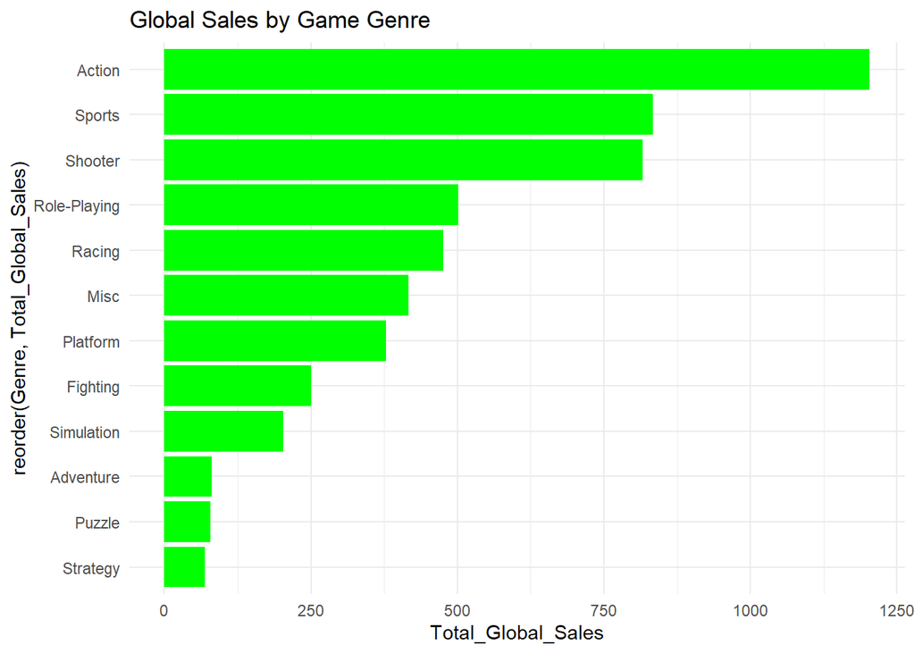

```r
games %>%
  group_by(Genre) %>%
  summarize(Total_Global_Sales = sum(Global_Sales)) %>%
  ggplot(aes(x = reorder(Genre, Total_Global_Sales), y = Total_Global_Sales)) +
  geom_bar(stat = "identity", fill = "green") +
  coord_flip() +
  theme_minimal() +
  ggtitle("Global Sales by Game Genre")
```

The above graph represents the total global sales of video games, grouped by their genre.

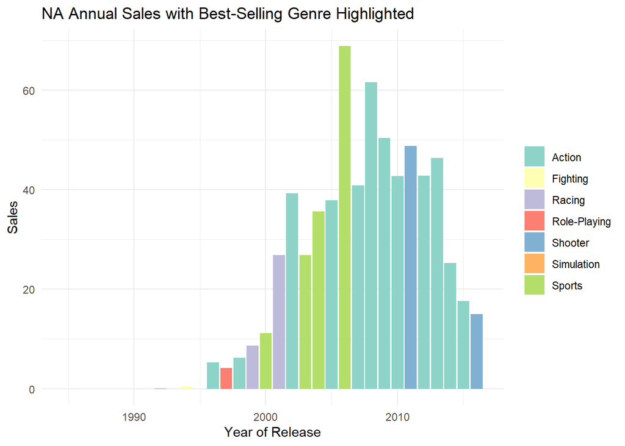

```r
library(dplyr)
library(ggplot2)
library(tidyr)
library(ggrepel)
games$Year_of_Release <- as.numeric(as.character(games$Year_of_Release))

na_sales <- games %>%
  group_by(Year_of_Release, Genre) %>%
  summarise(NA_Sales = sum(NA_Sales, na.rm = TRUE)) %>%
  ungroup()
na_best_selling_genres <- na_sales %>%
  arrange(desc(NA_Sales)) %>%
  group_by(Year_of_Release) %>%
  slice(1) %>%
  ungroup()

# Create a bar plot for NA region only with each genre a different color
na_genre_sales_plot <- ggplot(na_best_selling_genres, aes(x = Year_of_Release, y = NA_Sales, fill = Genre)) +
  geom_bar(stat = "identity", position = "dodge") +
  theme_minimal() +
  scale_fill_brewer(palette = "Set3") +
  labs(title = "NA Annual Sales with Best-Selling Genre Highlighted", x = "Year of Release", y = "Sales") +
  theme(legend.title = element_blank())

print(na_genre_sales_plot)
```

The graph displays the annual sales of the best-selling video game genres in North America, with each bar representing a specific year.

- A period dominated by action games might be followed by a surge in the popularity of sports games.

```r
# Load necessary libraries
library(dplyr)
library(caret)
```

```r
library(ggplot2)
library(reshape2)
# Assuming 'games_final' is your dataset
data <- games_final

# Define 'hit' games based on a threshold
hit_threshold <- quantile(data$Global_Sales, 0.75)
data$Hit <- ifelse(data$Global_Sales >= hit_threshold, 1, 0)
data$Hit <- as.factor(data$Hit)

# Function to bin categories
bin_categories <- function(column, top_n) {
  counts <- table(column)
  top_categories <- names(sort(counts, decreasing = TRUE)[1:top_n])
  column_binned <- ifelse(column %in% top_categories, column, "Others")
  return(column_binned)
}

# Bin 'Developer' category
data$Developer <- bin_categories(data$Developer, top_n = 10)

# Convert necessary variables to factors
data$Developer <- as.factor(data$Developer)
data$Platform <- as.factor(data$Platform)
data$Genre <- as.factor(data$Genre)
data$Year_of_Release <- as.numeric(as.character(data$Year_of_Release))

# Split data into training and testing sets
set.seed(123) # for reproducibility
index <- createDataPartition(data$Hit, p = 0.8, list = FALSE)
train_data <- data[index, ]
test_data <- data[-index, ]

# Fit a logistic regression model
logit_model <- glm(Hit ~ Critic_Score + Developer  + Genre ,
                   data = train_data, family = binomial())
print(summary(logit_model))
```

```
##
## Call:
## glm(formula = Hit ~ Critic_Score + Developer + Genre, family = binomial(),
##     data = train_data)
##
## Coefficients:
##                    Estimate Std. Error z value Pr(>|z|)
## (Intercept)       -4.639119   0.381704 -12.154  < 2e-16 ***
## Critic_Score       0.053450   0.003159  16.921  < 2e-16 ***
## Developer1553      0.309054   0.422558   0.731  0.46454
## Developer1561      0.390173   0.435695   0.896  0.37051
## Developer266      -0.145614   0.408228  -0.357  0.72132
## Developer307      -0.492524   0.489739  -1.006  0.31457
## Developer434      -0.130454   0.405546  -0.322  0.74770
## Developer452       0.556586   0.407152   1.367  0.17162
## Developer456       0.865595   0.435744   1.986  0.04698 *
## Developer480       0.516676   0.449320   1.150  0.25018
## Developer827      -0.289683   0.436706  -0.663  0.50712
## DeveloperOthers   -0.131287   0.329242  -0.399  0.69007
## GenreAdventure    -0.960955   0.242681  -3.960 7.50e-05 ***
## GenreFighting     -0.061046   0.160102  -0.381  0.70299
## GenreMisc          0.003359   0.161289   0.021  0.98338
## GenrePlatform      0.006520   0.158578   0.041  0.96720
## GenrePuzzle       -0.824972   0.318277  -2.592  0.00954 **
## GenreRacing       -0.135961   0.143275  -0.949  0.34265
## GenreRole-Playing -0.344525   0.129743  -2.655  0.00792 **
## GenreShooter       0.023498   0.118709   0.198  0.84309
## GenreSimulation   -0.325123   0.183257  -1.774  0.07604 .
## GenreSports       -0.210337   0.127580  -1.649  0.09922 .
## GenreStrategy     -1.142691   0.222714  -5.131 2.89e-07 ***
## ---
## Signif. codes:  0 '***' 0.001 '**' 0.01 '*' 0.05 '.' 0.1 ' ' 1
##
## (Dispersion parameter for binomial family taken to be 1)
##
##     Null deviance: 5558.4  on 4917  degrees of freedom
## Residual deviance: 5104.6  on 4895  degrees of freedom
## AIC: 5150.6
##
## Number of Fisher Scoring iterations: 4
```

```r
# Predict on test data
predictions <- predict(logit_model, newdata = test_data, type = "response")
predicted_class <- ifelse(predictions > 0.5, 1, 0)
predicted_class <- factor(predicted_class, levels = levels(test_data$Hit))

# Create a confusion matrix
conf_matrix <- confusionMatrix(predicted_class, test_data$Hit)

print(conf_matrix)
```

```
## Confusion Matrix and Statistics
##
##           Reference
## Prediction   0   1
##          0 897 273
##          1  21  37
##
##                Accuracy : 0.7606
##                  95% CI : (0.7357, 0.7842)
##     No Information Rate : 0.7476
##     P-Value [Acc > NIR] : 0.1542
##
##                   Kappa : 0.132
##
##  Mcnemar's Test P-Value : <2e-16
##
##             Sensitivity : 0.9771
##             Specificity : 0.1194
##          Pos Pred Value : 0.7667
##          Neg Pred Value : 0.6379
##              Prevalence : 0.7476
##          Detection Rate : 0.7305
##    Detection Prevalence : 0.9528
##       Balanced Accuracy : 0.5482
##
##        'Positive' Class : 0
##
```

```r
# Load necessary libraries
library(dplyr)
library(caret)
library(pROC)
```

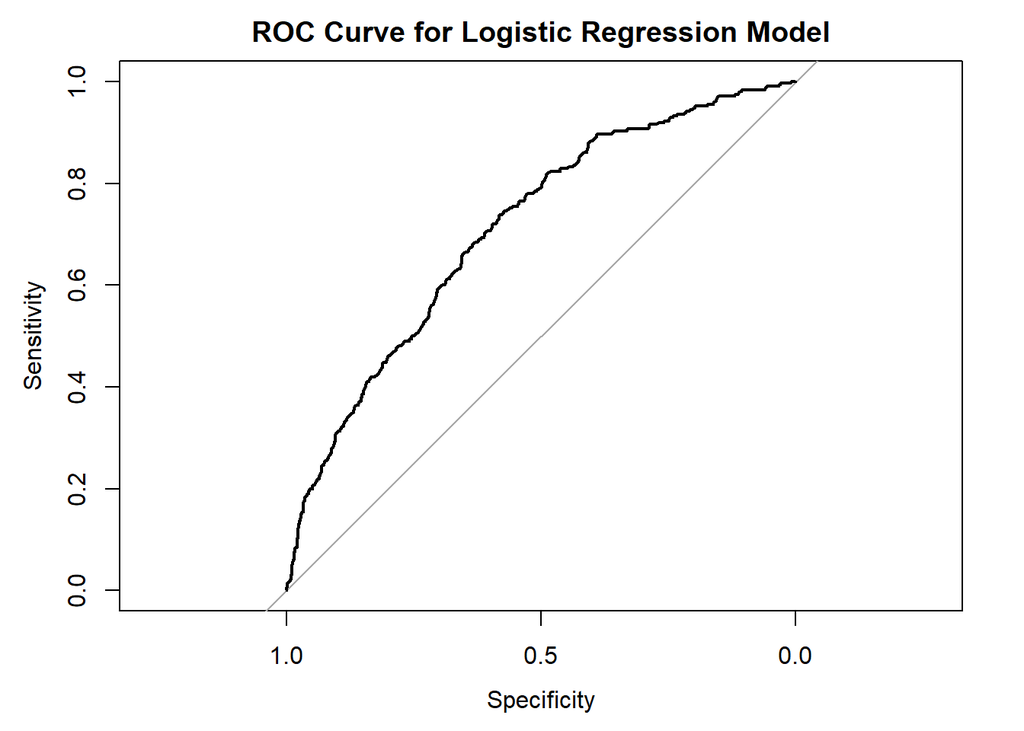

```r
# [Previous code for data preparation, logistic regression model training, and predictions]

# Calculate the ROC curve
roc_obj <- roc(test_data$Hit, as.numeric(predictions))
# Plot the ROC curve
plot(roc_obj, main = "ROC Curve for Logistic Regression Model")
```

```r
# Print AUC (Area Under the Curve)
auc(roc_obj)
```

```
## Area under the curve: 0.7107
```

```r
# Assuming you have 'predictions' and 'test_data$Hit' from your logistic regression model
predicted_class <- ifelse(predictions > 0.5, "1", "0")
predicted_class <- factor(predicted_class, levels = c("0", "1"))

# Actual values
actual_class <- test_data$Hit

# Create a table for Actual vs Predicted
confusion_matrix <- table(Predicted = predicted_class, Actual = actual_class)

# Print the confusion matrix
print(confusion_matrix)
```

```
##          Actual
## Predicted   0   1
##         0 897 273
##         1  21  37
```

We are using logistic regression model to predict if a games is hit or not based on the threshold value. we are using **Critic Score** , **Developer** and **Genre** as predicotrs. For making logistic model at first we are using binning function. Binning top developers because there are likely many unique developers in the dataset. Without binning, the model would have too many variables (one for each developer), many of which would have little data, leading to overfitting and making the model less generalizable. By binning, you reduce the complexity of the model and focus on the most common developers.

**Coefficients and p-values:** These values represent the change in the log odds of the dependent variable (in your case, whether a game is a ‘hit’ or not) for a one-unit change in the predictor.

**Critic_Score (Coefficient: 0.053450, p-value: < 2e-16)** * This is a highly significant predictor. The positive coefficient indicates that higher critic scores are associated with a higher likelihood of a game being a hit. The extremely low p-value suggests this relationship is statistically significant.

**Developer456 (Coefficient: 0.865595, p-value: 0.04698)**

- This specific developer (represented as ‘Developer456’) has a positive impact on the likelihood of a game being a hit. The p-value is just under 0.05, indicating that this result is statistically significant, although it’s on the borderline.

**GenreAdventure (Coefficient: -0.960955, p-value: 7.50e-05)**

- Being an adventure game is associated with a lower likelihood of being a hit, as indicated by the negative coefficient. The p-value is very small, showing strong evidence against the null hypothesis.

**GenrePuzzle (Coefficient: -0.824972, p-value: 0.00954)**

Puzzle games are also less likely to be hits. The negative coefficient and its low p-value signify a strong and statistically significant relationship.

**GenreRole-Playing (Coefficient: -0.344525, p-value: 0.00792)**

- Role-Playing games have a negative coefficient, suggesting they are less likely to be hits compared to the baseline genre. The p-value indicates this finding is statistically significant.

**GenreStrategy (Coefficient: -1.142691, p-value: 2.89e-07)**

- Strategy games show a strong negative association with being a hit. The coefficient is significantly negative, and the very low p-value strongly supports its significance.

**Null Devience:**

- Null deviance shows the goodness of fit of a model with no predictors (only the intercept) and residual deviance shows the goodness of fit of your model. A lower residual deviance compared to the null deviance indicates that the model is a better fit than the null model.

**Accuracy(0.7606):** * The above model has an accuracy of 76.06%, which means it correctly predicts whether a game is a hit or not 76.06% of the time.

**Confusion Matrix:**